# Basics of R Programming Language

## Bar chart

Let’s create a bar chart of the number of patients based on different melanoma type in `melanoma_data` instrument.

The `geom_bar` is the geom used to plot bar charts. It requires a single aesthetic mapping of the categorical variable of interest to `x`.

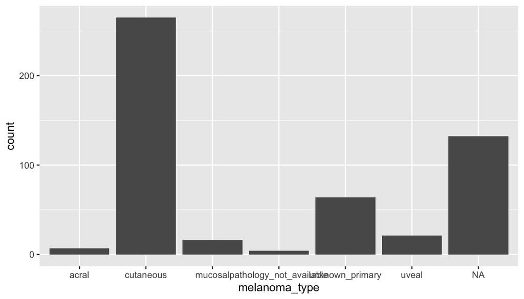

```r
ggplot(immuno_dataset$redcap_data$melanoma_data) +
  geom_bar(aes(x = melanoma_type))
```

The dark grey bars are a big ugly - what if we want each bar to be a different colour?

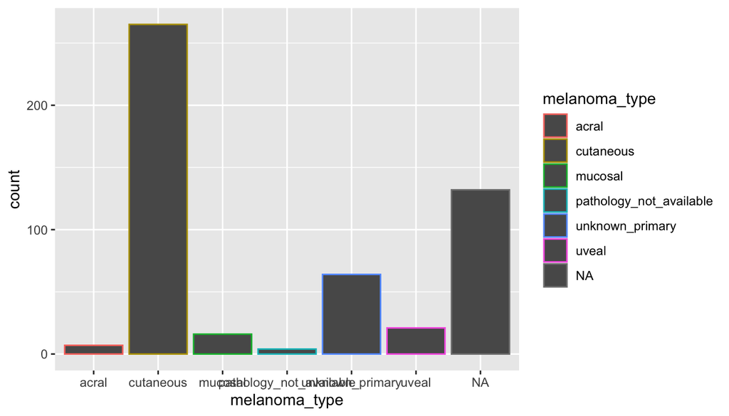

```r
ggplot(immuno_dataset$redcap_data$melanoma_data) +
  geom_bar(aes(x = melanoma_type, colour = melanoma_type))
```

Colouring the edges wasn’t quite what we had in mind. Look at the help for `geom_bar` to see what other aesthetic we should have used.

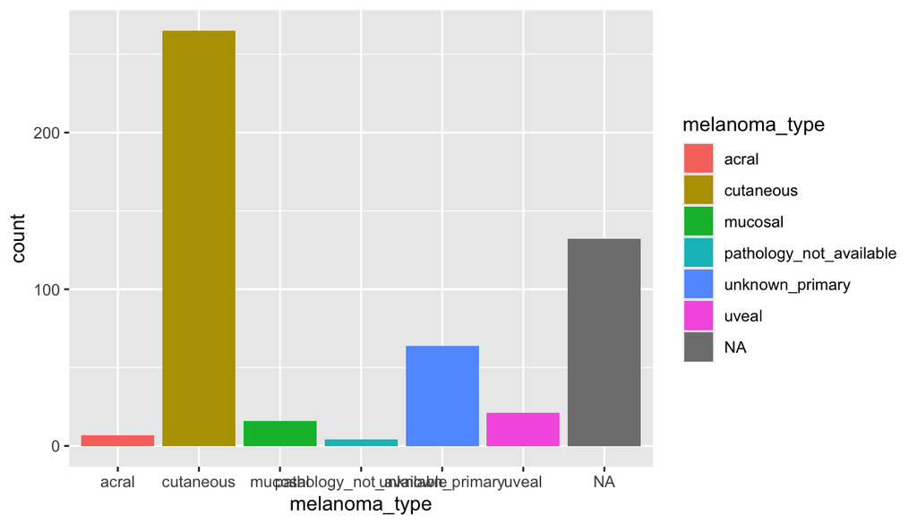

```r
ggplot(immuno_dataset$redcap_data$melanoma_data) +
  geom_bar(aes(x = melanoma_type, fill = melanoma_type))
```

What happens if we colour (fill) with something other than the `melanoma_type`?

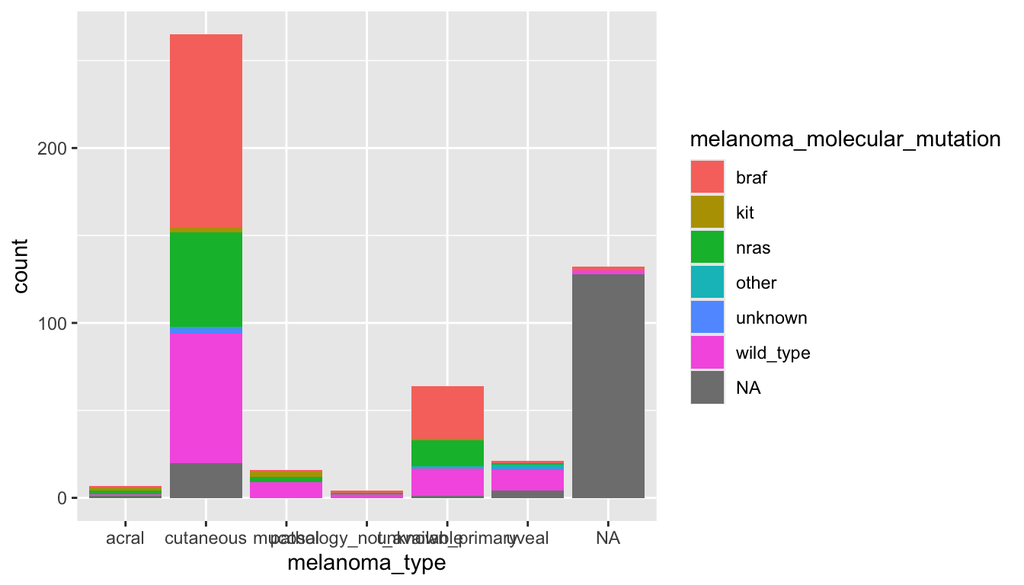

```r
ggplot(immuno_dataset$redcap_data$melanoma_data) +
  geom_bar(aes(x = melanoma_type, fill = melanoma_molecular_mutation))
```

We get a stacked bar plot.

Note the similarity in what we did here to what we did with the scatter plot - there is a common grammar.

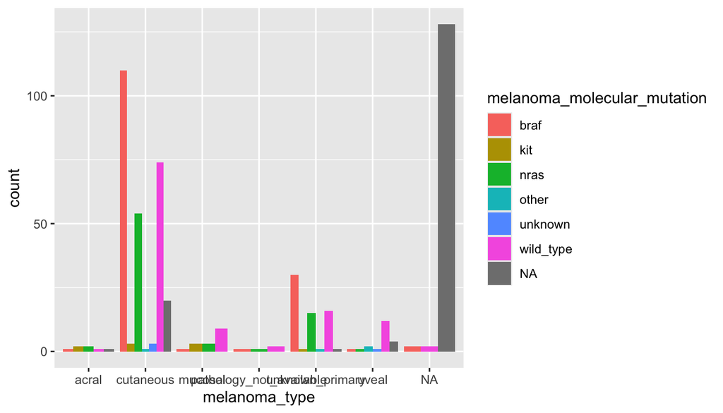

```r
ggplot(immuno_dataset$redcap_data$melanoma_data) +
  geom_bar(aes(x = melanoma_type, fill = melanoma_molecular_mutation), position = 'dodge')
```

What if want all the bars to be the same colour but not dark grey, e.g. blue?

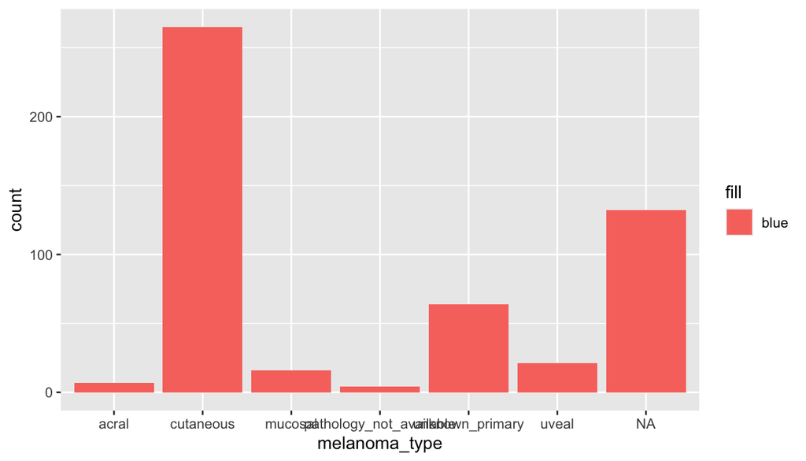

```r
ggplot(immuno_dataset$redcap_data$melanoma_data) +
  geom_bar(aes(x = melanoma_type, fill = "blue"))
```

That doesn’t look right - why not?

You can set the aesthetics to a fixed value but this needs to be outside the mapping, just like we did before for size and transparency in the scatter plots.

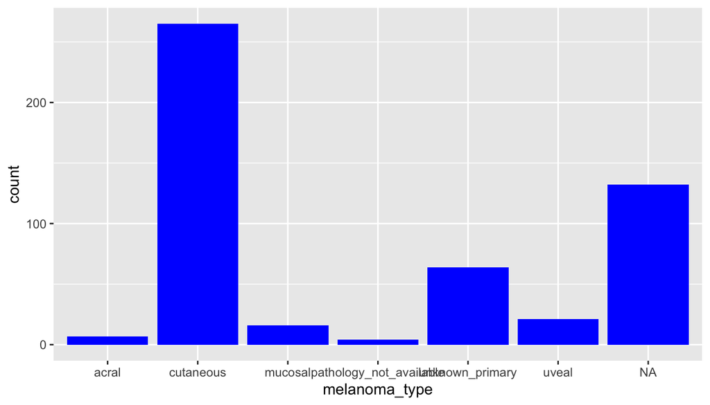

```r
ggplot(immuno_dataset$redcap_data$melanoma_data) +
  geom_bar(aes(x = melanoma_type), fill = "blue")
```

Setting this inside the `aes()` mapping told ggplot2 to map the colour aesthetic to some variable in the data frame, one that doesn’t really exist but which is created on-the-fly with a value of “blue” for every observation.

## Box plot

Box plots (or *box & whisker plots*) are a particular favourite seen in many seminars and papers. Box plots summarise the distribution of a set of values by displaying the minimum and maximum values, the median (i.e. middle-ranked value), and the range of the middle 50% of values (inter-quartile range). The whisker line extending above and below the IQR box define Q3 + (1.5 x IQR), and Q1 - (1.5 x IQR) respectively.

[figure not shown]

To create a box plot from immuno dataset:

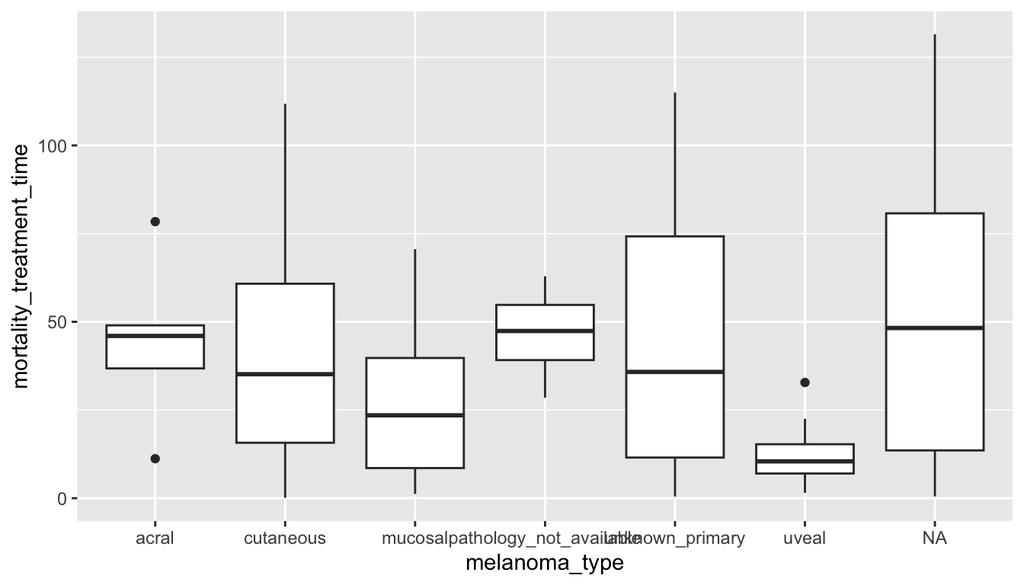

```r
# join the melanoma_data instrument and mortality_data
mel_mort <- full_join(immuno_dataset$redcap_data$melanoma_data ,
                      immuno_dataset$redcap_data$mortality_data,
                      by = "record_id")
# keep only the non-missing rows of mortality_treatment_time column
mel_mort <- mel_mort |> filter(!is.na(mortality_treatment_time))

ggplot(mel_mort, aes(x = melanoma_type, y = mortality_treatment_time)) +
  geom_boxplot()
```

See `geom_boxplot` help to explain how the box and whiskers are constructed and how it decides which points are outliers and should be displayed as points.

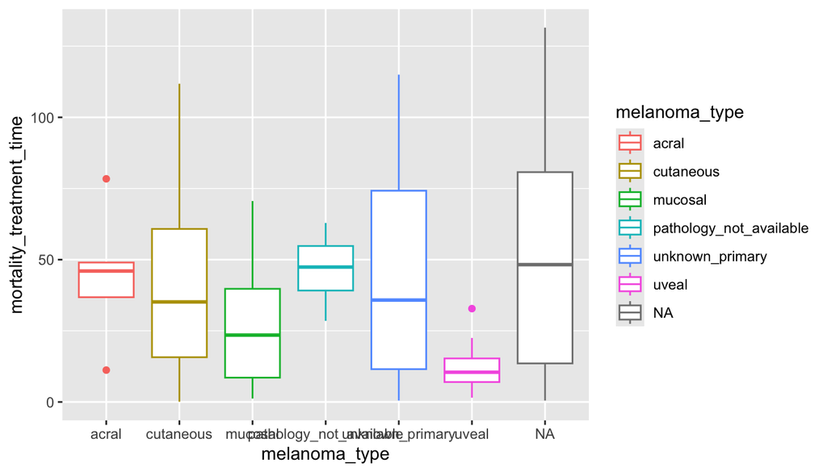

```r
ggplot(mel_mort, aes(x = melanoma_type, y = mortality_treatment_time, color = melanoma_type)) +
  geom_boxplot()
```

## Violin plot

A *violin plot* is used to visualise the distribution of a numeric variable across different categories. It combines aspects of a box plot and a kernel density plot.

The width of the violin at any given point represents the density of data at that point. Wider sections indicate a higher density of data points, while narrower sections indicate lower density. By default, violin plots are symmetric.

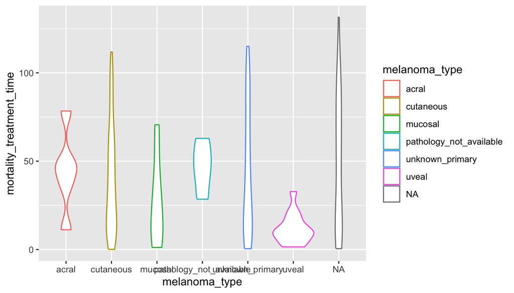

```r
ggplot(mel_mort, aes(x = melanoma_type, y = mortality_treatment_time, color = melanoma_type)) +
    geom_violin()
```

## Histogram

The geom for creating histograms is, rather unsurprisingly, `geom_histogram()`.

```
Warning: Removed 155 rows containing non-finite outside the scale range
(`stat_bin()`).
```

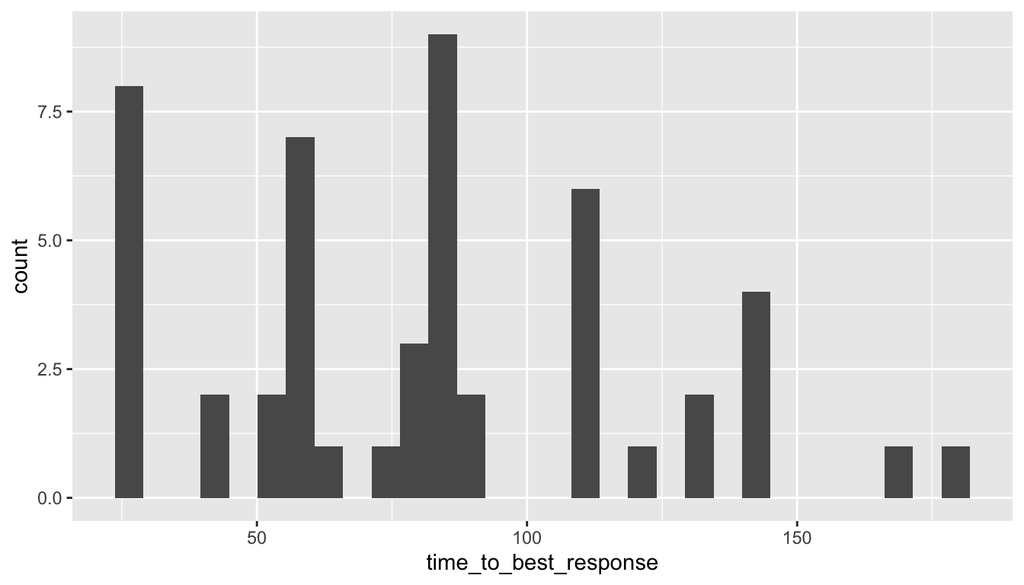

```r
ggplot(immuno_dataset$redcap_data$response_data) +
  geom_histogram(aes(x = time_to_best_response))
```

```
Warning: Removed 155 rows containing non-finite outside the scale range
(`stat_bin()`).
```

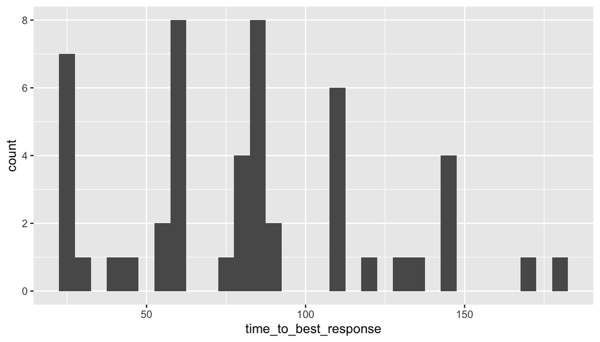

```r
ggplot(immuno_dataset$redcap_data$response_data) +
  geom_histogram(aes(x = time_to_best_response), binwidth = 5)
```

Or we can set the number of bins.

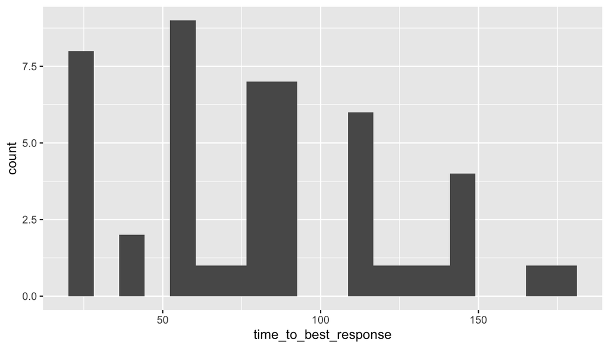

```r
ggplot(immuno_dataset$redcap_data$response_data) +
  geom_histogram(aes(x = time_to_best_response), bins = 20)
```

These histograms are not very pleasing, aesthetically speaking - how about some better aesthetics?

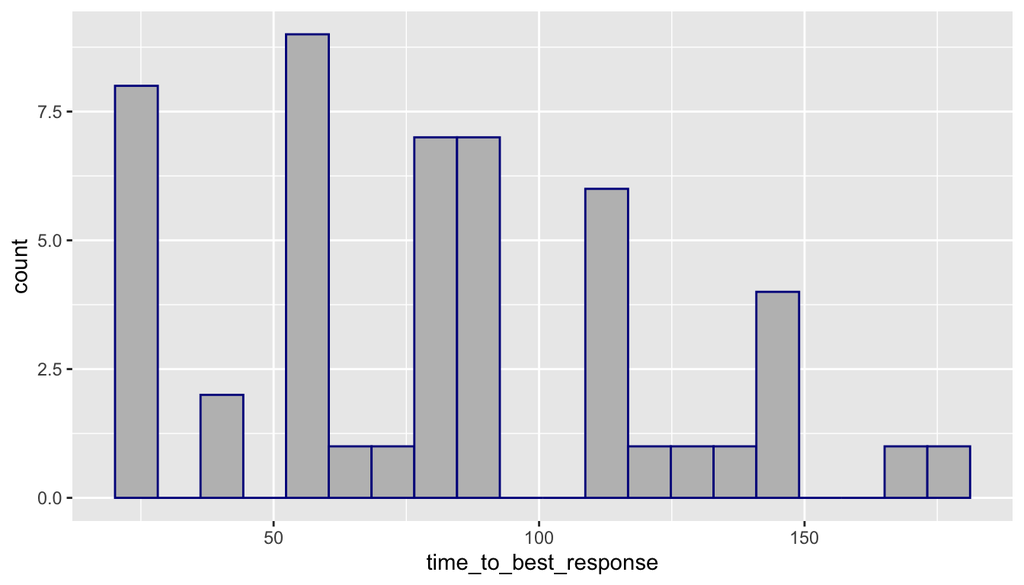

```r
ggplot(immuno_dataset$redcap_data$response_data) +
  geom_histogram(
    aes(x = time_to_best_response),
    bins = 20,
    colour = "darkblue",
    fill = "grey")
```

## Density plot

Density plots are used to visualise the distribution of a continuous variable in a dataset. These are essentially smoothed histograms, where the area under the curve for each sub-group will sum to 1. This allows us to compare sub-groups of different size.

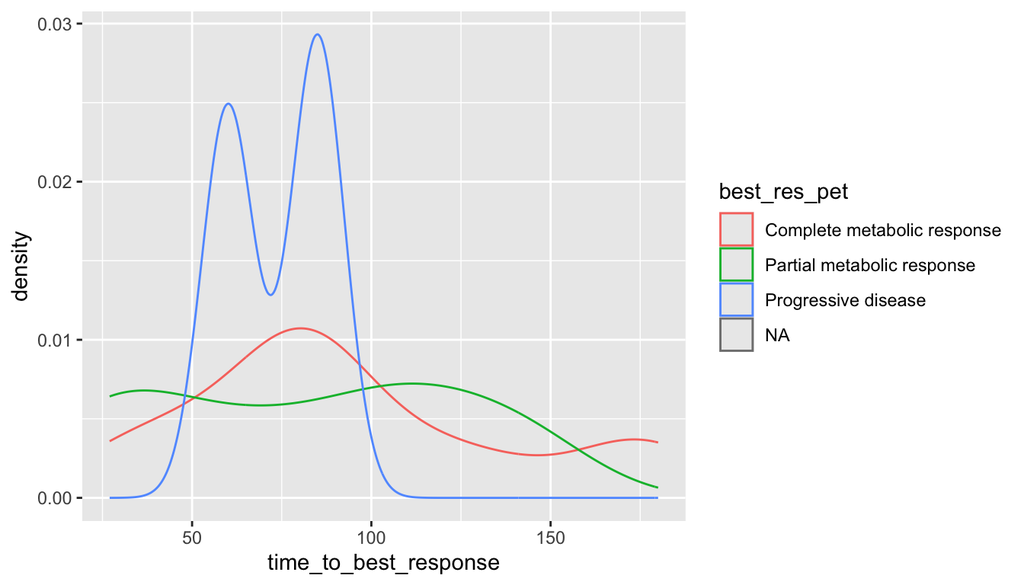

```r
ggplot(immuno_dataset$redcap_data$response_data) +
  geom_density(aes(x = time_to_best_response, colour = best_res_pet))
```

## Saving plot images

Use `ggsave()` to save the last plot you displayed.

```r
ggsave("time_to_best_response_density_plot.png")
```

You can alter the width and height of the plot and can change the image file type.

```r
ggsave("time_to_best_response_density_plot.pdf", width = 20, height = 12, units = "cm")
```

You can also pass in a plot object you have created instead of using the last plot displayed. See the help page (`?ggsave`) for more details.